# Immigrant Apprehensions in the US’ Southwest Border

A Time Series Analysis of Migration Trends (2000–2025)

Paola Pavón

2025-04-08

[View this report online](https://mellow-lily-332675.netlify.app/)

## Introduction

Migration at the U.S. Southern Border is a complex and highly debated issue, shaped by a mix of political, economic, social, and environmental factors. In recent decades, the number of migrant encounters at the Southwest Border has fluctuated in response to both structural pressures in sending countries as well as changes in U.S. immigration policy. Understanding these fluctuations calls for a rigorous, data-driven analysis grounded in time series methods.

This report investigates the evolution of migrant apprehensions at the U.S.–Mexico border from 2000 to 2025, with a particular focus on identifying long-term trends, seasonal patterns, and structural changes across different presidential administrations. The analysis also explores how apprehensions relate to conditions in Mexico, including economic activity and insecurity, and climate in El Paso, Texas. By applying classical time series tools such as decomposition and correlation analysis, the goal is to discover the dynamics underlying migration patterns and assess how they respond to both domestic and international influences.

## Obtaining the data

The data collection process revealed important considerations and limitations that shaped the structure of this analysis. Border apprehension data has been recorded annually since the 1960s, but it wasn’t until October 1999 that the U.S. Customs and Border Protection (CBP) began reporting at a monthly resolution. Therefore, this marks the beginning of our time series.

Additionally, the fiscal year used by the U.S. Customs Service does not align with the calendar year. For example, the “2000” report actually reflects data from October 1999 to September 2000. This required special care during data cleaning and alignment, as something reported like “October 2000” actually meant October 1999.

After September 2019, a shift in reporting style introduced new categories such as *inadmissibles, expulsions*, and *apprehensions*. This project focuses exclusively on the last two.

Finally, the dataset ends in February 2025, which means the most recent policy impacts (e.g., from the 2024 U.S. election) are not yet captured.

### Why Focus on Mexico?

Mexico accounts for the largest share of migrant apprehensions at the U.S. Southwest Border in recent years. According to official encounter statistics between 2019 and 2022, over 2 million Mexican nationals were apprehended — significantly more than any other nationality. The latter justifies a focused analysis on Mexican variables such as economic activity and public security to understand how these internal conditions may shape migratory pressure. While migration from Central America and other regions has grown, Mexico remains the most consistently represented group in border enforcement data.

Table 1: U.S. Border Apprehensions by Country of Origin (2019–2022)

| Country | 2019 | 2020 | 2021 | 2022 | GrandTotal |
| --- | --- | --- | --- | --- | --- |
| Mexico | 166,458 | 131,057 | 608,037 | 1,522,740 | 2,428,292 |
| Guatemala | 185,535 | 41,512 | 283,771 | 228,258 | 739,076 |
| Honduras | 190,872 | 39,327 | 309,174 | 221,684 | 761,057 |
| El Salvador | 71,501 | 13,269 | 93,780 | 53,787 | 232,337 |
| Other | 216,569 | 72,991 | 262,249 | 379,282 | 931,091 |
| Unknown | 21,073 | 452 | 1,332 | 585 | 23,442 |

## Creating the time series

Once the data was cleaned and aligned across years, we proceeded to create the time series using R’s ts() function. This allowed us to explore the evolution of monthly apprehensions at the U.S. Southwest Border over more than two decades.

Our first time series plot already communicated several key insights:

**Figure 1.** *Monthly Migrant Apprehensions at the U.S. Southwest Border (2000–2025)*

[interactive chart not shown]

- **A clear long-term trend:** Apprehensions steadily declined from the early 2000s until around 2011. However, from 2017 onward, the trend reversed dramatically. Our first guess was that this change followed Trump’s anti-migration policies.
- **Seasonality:** A regular, recurring spike can be observed almost every year — most notably around the spring months, which we later confirm aligns with March.
- **Sharp increases in recent years:** Particularly after 2019, apprehension levels surged, peaking around 2022–2023.
- **Historical lows and highs:** The lowest point occurs in April 2020, likely due to the start of the COVID-19 pandemic. Likewise, late 2023 marks the highest number of apprehensions in the entire dataset.

## Trend Analysis

The chart below visualizes the monthly total migrant apprehensions at the U.S. Southwest Border from 2000 to early 2025. The black line shows raw monthly data, while the red line represents a 12-month moving average, helping us identify underlying trends.

**Figure 2.** *Monthly Migrant Apprehensions with 12-Month Moving Average*

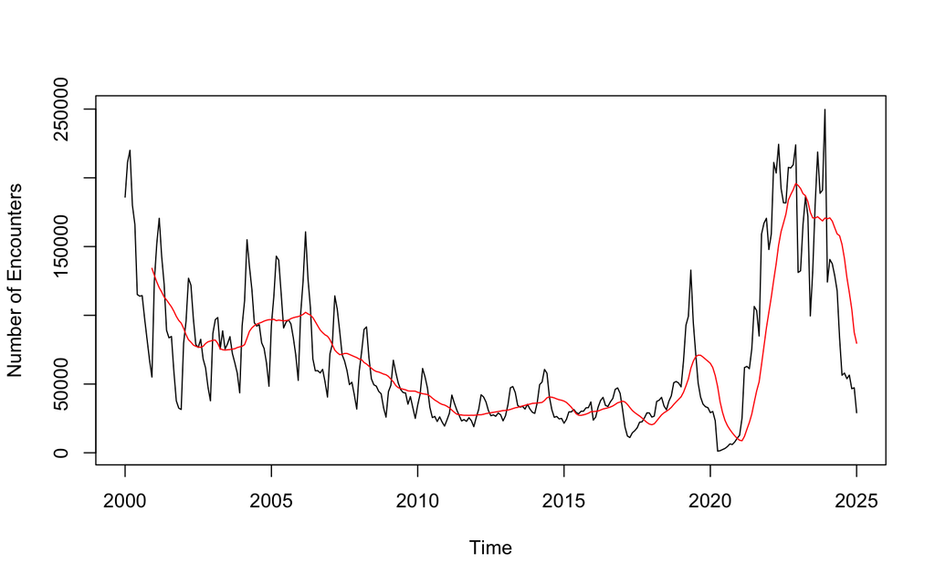

Several key patterns emerge from this graph:

- **Early 2000s Decline:** Apprehensions steadily decreased from 2000 to around
2011. This could reflect improved border enforcement, declining Mexican migration due to demographic and economic changes, or shifts in U.S. policy.
- **Stability (2012–2017):** Apprehensions remained relatively low and stable during this period. This includes much of the Obama administration’s second term, where enforcement continued but without dramatic new measures.
- **Sharp Increase Post-2017:** From 2017 onward, apprehensions grew significantly. This aligns with the beginning of Donald Trump’s presidency and his administration’s restrictive immigration policies. Rather than discouraging migration, some policies (e.g. *Remain in Mexico*) may have led to increased border crossings under worsening conditions.
- **Pandemic Dip in 2020:** The steep decline in early 2020 corresponds with the onset of COVID-19 and temporary border closures. The immediate drop highlights how public health emergencies can disrupt migration flows.
- **Post-2020 Spike:** From mid-2020 through 2023, apprehensions reached historic highs — particularly under President Biden’s term. This could reflect a combination of higher migration demand after pandemic disruptions, shifting enforcement practices, and worsening conditions in migrants’ home countries.

This long-term view shows that while migration patterns can be influenced by policy, they are also shaped by broader social, economic, and environmental forces — many of which transcend national boundaries.

## Seasonality Analysis

To better understand the underlying structure of migrant apprehension data, we applied the decompose() function in R. This function separates a time series into three key components:

- **Trend:** The long-term movement in the data, ignoring short-term fluctuations.
- **Seasonal:** The recurring, systematic patterns that repeat over a fixed period (e.g., every 12 months).
- **Random (or Residual):** The irregular, unexplained variation remaining after removing the trend and seasonal patterns.

**Figure 3.** *Time Series Decomposition of Apprehensions*

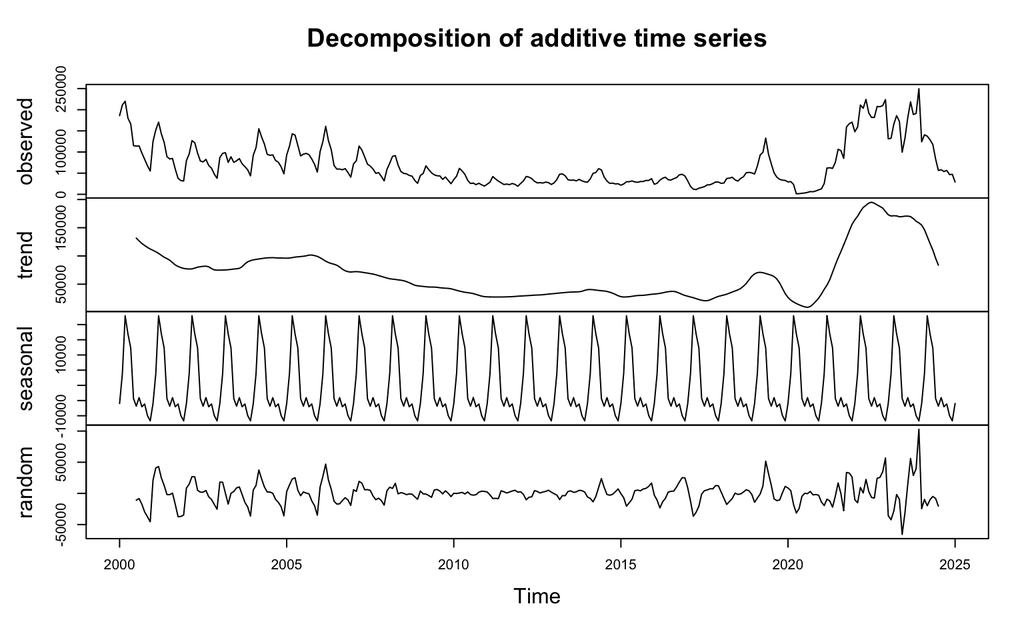

The plot generated by this function provided crucial insights:

The strength of this approach is that it helps isolate what’s systematic vs. what’s unexpected, allowing for clearer interpretation of the driving forces behind the data.

Moreover, we created a barplot to highlight how apprehension levels deviate from the average across months. The most striking observation is the sharp spike in March, followed by elevated levels in April and May, and then a decline into the summer and fall months.

**Figure 4.** *Average Seasonal Pattern of Apprehensions by Calendar Month*

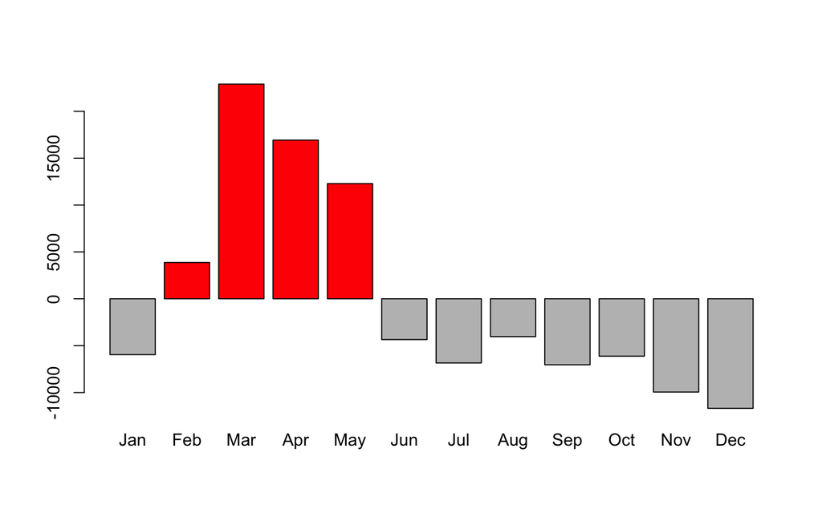

This seasonal pattern likely reflects environmental realities faced by migrants. Crossing the U.S.–Mexico border involves walking through the desert, where extreme temperatures pose serious risks. The spring months offer a window of moderate weather, reducing the physical dangers associated with both winter cold and summer heat.

## Correlations

In order to understand the broader determinants of migration flows, we analysed whether U.S. border apprehensions correlate with economic and security variables in Mexico, as well as with climatic variables in El Paso, Texas. The results reveal nuanced and sometimes surprising insights.

### Economic Growth

To assess whether economic conditions in Mexico influence migration, I used the *Indicador Global de la Actividad Económica (IGAE)* — a monthly index published by *INEGI*, Mexico’s national statistics agency. The *IGAE* serves as a high-frequency proxy for GDP, reflecting the country’s overall economic performance by aggregating data from key sectors such as industry, services, and agriculture.

Despite the intuitive expectation that migration might increase during periods of economic distress, the correlation between monthly apprehensions and the *IGAE* index is zero (cor = 0.00026). As shown in this first scatter plot, there is no visible relationship between the two variables. This suggests that the national-level economic performance captured by *IGAE* may not have a direct or immediate impact on **monthly** migration flows. Other forces, such as insecurity or U.S. policy, may be more influential. It would be interesting to observe if, when transforming data to annual and using **actual** gdp data, this correlation grows.

**Figure 5.** *Apprehensions vs. Mexican Economic Activity (IGAE Index)*

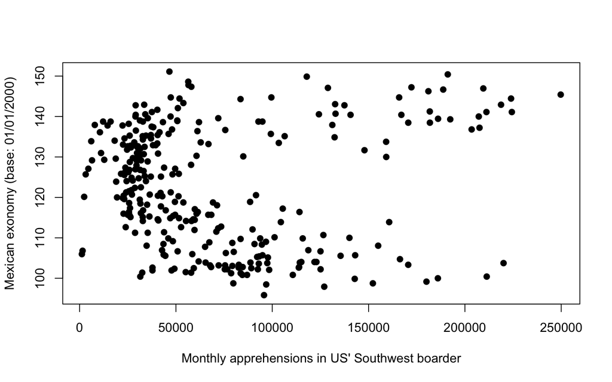

### Insecurity (Homicides in Mexico)

To explore the potential impact of violence on migration, we used monthly homicide statistics also published by *INEGI*. The data was retrieved through their multidimensional query system (*INEGI, OLAP Homicide Database*), which provides disaggregated information by month.

Contrary to what one might intuitively assume, there is a slightly negative correlation between monthly apprehensions and homicide counts (cor = -0.1163). The second scatter plot shows that higher levels of violence do not necessarily lead to increased migration. One possible explanation is a *“frozen conflict”* effect: in areas plagued by extreme cartel violence, people may be less able or willing to leave due to fear, limited mobility, or blocked transit routes. In such contexts, the most vulnerable populations may become immobilized rather than mobilized — effectively trapped in violent environments.

This insight highlights that insecurity does not always result in higher migration — especially when insecurity becomes so severe that it disrupts the ability to escape.

**Figure 6.** *Apprehensions vs. Homicide Counts in Mexico (INEGI)*

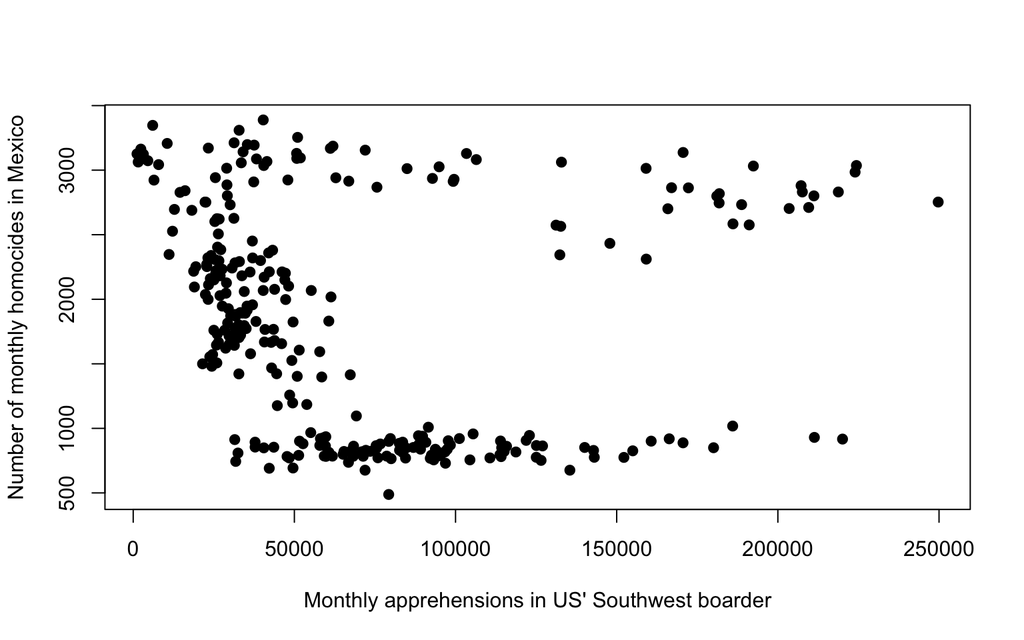

### Climate (Average Monthly Temperature)

To examine whether climate conditions influence migration, we used monthly average temperature data from El Paso, Texas — a key border crossing area. This dataset was sourced from the *National Centers for Environmental Information (NCEI)* via *NOAA’s Climate at a Glance* portal.

The observed correlation between temperature and apprehensions was very weak and slightly negative (cor = -0.0056). At first glance, this suggests temperature has little to no influence on migration. However, this result may be misleading due to the nonlinear nature of the relationship.

It is possible that migration attempts decrease during both temperature extremes: when temperatures are too high, the desert crossing becomes life-threatening; when they are too low, especially during winter nights, the risk of hypothermia also discourages movement. This would result in the highest migration activity occurring during moderate spring temperatures — such as in March, when we observe seasonal peaks.

In such cases, the correlation appears flat not because there’s no relationship, but because the relationship is U-shaped or threshold-based rather than linear. A more accurate analysis could involve nonlinear models, temperature thresholds, or categorizing the year into climate zones (e.g., *mild, hot, cold*) to assess their effects separately.

**Figure 7.** *Apprehensions vs. Average Monthly Temperature (El Paso)*

[interactive chart not shown]

## Political Cycles and Presidential Effects

To better understand how U.S. political leadership may influence migration patterns, we overlaid presidential transitions onto the apprehensions time series using vertical dashed lines. Each change in administration is marked with its respective president’s name and party color: red for Republicans (Bush, Trump) and blue for Democrats (Obama, Biden).

**Figure 8.** *Apprehensions Over Time vs U.S. Presidential Administration Markers*

[interactive chart not shown]

### Statistical Comparison by Presidency

To test whether these visual differences were statistically meaningful, we calculated the mean number of apprehensions under each administration and constructed 95% confidence intervals:

- **Bush:** (79,302 – 84,773)
- **Obama:** (33,904 – 35,654)
- **Trump:** (30,519 – 37,082)
- **Biden:** (126,531 – 141,693)

As we can observe, Trump’s and Obama’s confidence intervals overlap, suggesting no statistically significant difference in average apprehensions between their terms. This could be possibly due to the short duration of Trump’s presidency (4 years) when compared to Obama’s (8 years).

However, when comparing:

- **Before vs. After Trump:**
  - **Before:** (60,609 – 65,215)
  - **After:** (79,256 – 91,230)

we do observe a significant difference. And more importantly:

- **Before vs. After Biden:**
  - **Before:** (55,340 – 59,456)
  - **After:** (129,205 – 144,074)

There is a clear and statistically significant difference. The sharp rise in the Biden era stands out as an **unprecedented shift**.

### Interpretation

This analysis suggests that while Trump’s rhetoric and border policies likely had a long-term effect, **the largest increase in migration activity occurred under the Biden administration**. Despite President Biden’s campaign promises to implement more humane immigration policies, his administration saw the highest number of border apprehensions in the dataset. This apparent contradiction can be explained by a combination of structural, policy, and contextual factors.

Upon taking office, Biden rolled back several Trump-era enforcement measures, including ending the *Remain in Mexico* policy *(MPP)* and narrowing ICE deportation priorities. These changes, while framed as humanitarian, may have been interpreted by migrants as a “green light”, encouraging more attempts to cross the border. At the same time, an excess of migration demand that had been postponed during the COVID-19 pandemic surged in 2021, compounding the pressure at the border. Although the Biden administration retained Title 42 — a public health rule enabling immediate expulsions — the lack of legal consequences for those expelled led many migrants to **attempt multiple crossings** , artificially inflating apprehension figures. Ultimately, the spike in apprehensions during Biden’s presidency reflects not only policy changes but also a confluence of broader humanitarian crises and post-pandemic pressures.

It’s important to interpret these results with nuance — **correlation does not imply causation** — but the data suggests that U.S. political leadership and enforcement strategies do impact migration flows, even if other structural forces also play a role.

## Conclusion

This analysis used monthly data from 2000 to early 2025 to examine the temporal dynamics of migrant apprehensions at the U.S. Southwest Border. Through a time series framework, we identified strong seasonal patterns, a reversal in long-term trends, and significant structural breaks that coincide with political transitions and global shocks.

Our decomposition analysis confirmed a pronounced seasonality, with consistent migration peaks in March, likely linked to favorable crossing conditions. The trend component revealed a long decline from 2000 to 2011, a stability through 2017, and then an acceleration in apprehensions from there onward.

In summary, time series analysis reveals that **migration flows are shaped by the interaction of seasonality, policy shifts, and external shocks**, rather than any single driver. These findings highlight the utility of decomposition, correlation, and structural comparison techniques in disentangling short-term fluctuations from longer-term trends — and demonstrate the power of time series methods to explore politically and socially complex phenomena.

## Sources

- **U.S. Border Patrol Monthly Apprehensions** U.S. Customs and Border Protection (CBP). Retrieved from: https://www.cbp.gov/newsroom/stats/southwest-land-border-encounters
- **Mexico’s Economic Activity (IGAE)** Instituto Nacional de Estadística y Geografía (INEGI). Retrieved from: https://www.inegi.org.mx/temas/igae/
- **Homicide Data in Mexico** INEGI OLAP multidimensional query system. Retrieved from: https://www.inegi.org.mx/sistemas/olap/proyectos/bd/continuas/mortalidad/defuncioneshom.asp?s=est#
- **Climate Data for El Paso, Texas** National Centers for Environmental Information (NCEI), NOAA. Retrieved from: https://www.ncei.noaa.gov/access/monitoring/climate-at-a-glance/city/time-series/USW00023044/tavg/1/0/2000-2025